# Simple Regression with brms (Exercise)

Vedant Shah 987144

04/20/2020

## Exercise 2 *HOMEWORK*

- If you need help, take a look at the suggested readings in the lecture, make use of the Forum, make use of the Forum, and also make use of the Forum.
- Use this exercise Rmd-file, solve the exercises marked as homework (this section here) and save the file with your student number and name in the âauthorâ heading.
- âKnitâ the document to produce a HTML file. If knitting fails, make use of the Forum ;)
- **Please do not suppress the code in the HTML-Output!**
- Create a ZIP archive called âMATRIKELNR_Lastname_Firstname_ABDA_Week3.zipâ containing:
- an R Markdown file âMATRIKELNR_Lastname_Firstname_ABDA_Week3.Rmdâ and
- a knitted HTML document âMATRIKELNR_Lastname_Firstname_ABDA_Week3.htmlâ
- Upload the ZIP archive on Stud.IP in the homework folder before the deadline. You may upload as many times as you like before the deadline, only your final submission will count.

I prepared an aggregated data frame `dolphin_agg2` for you.

```r
# make correct a factor
dolphin$correct <- as.factor(dolphin$correct)

# aggregate
dolphin_agg2 <- dolphin %>%
  group_by(exemplar, group, condition, correct) %>%
  dplyr::summarize(MAD = median(MAD, na.rm = TRUE))
```

1. Plot the data (for all combinations of `group`, `condition`, and `correct`) as a point plot. Use `facet_grid` and dodged positions to separate the categories.

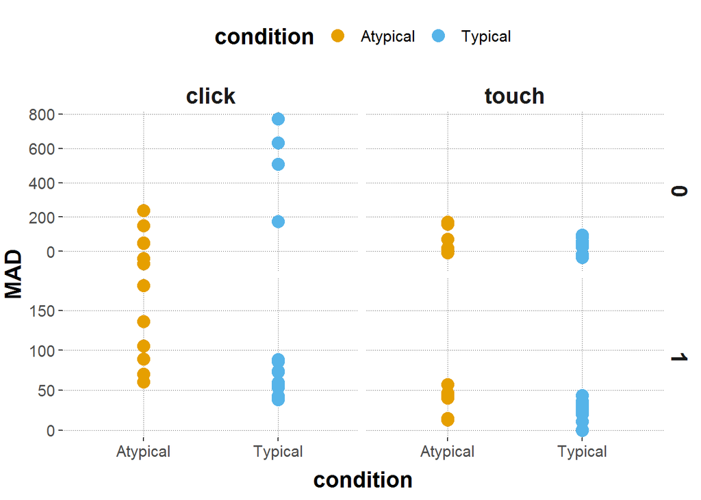

```r
ggplot() +
  geom_point(data = dolphin_agg2,
       aes(x = condition, y = MAD,
           color = condition, fill = condition), position = position_dodge(width = 0.7), size = 4, alpha = 1) +
  facet_grid(correct~group, scales= "free")
```

2. Run a linear model with `brm` with the dependent variable `MAD` and the independent variables `group`, `condition`, `correct` and an 2-way interaction term for `group x condition`. Run 4 chains, and 2000 iteration per chain. Use `seed = 991`.

```r
model = brm(
  # model formula
  MAD ~ (condition * group) + correct,
  # data
  data = dolphin_agg2,
  seed = 991,
  iter   = 2000,
  chains = 4
  )
summary(model)
```

```
##  Family: gaussian
##   Links: mu = identity; sigma = identity
## Formula: MAD ~ (condition * group) + correct
##    Data: dolphin_agg2 (Number of observations: 65)
## Samples: 4 chains, each with iter = 2000; warmup = 1000; thin = 1;
##          total post-warmup samples = 4000
##
## Population-Level Effects:
##                             Estimate Est.Error l-95% CI u-95% CI Rhat
## Intercept                     126.97     38.16    52.10   200.83 1.00
## conditionTypical              109.79     46.25    20.86   201.38 1.00
## grouptouch                    -31.71     48.98  -131.65    66.18 1.00
## correct1                      -96.17     31.38  -155.71   -33.72 1.00
## conditionTypical:grouptouch  -130.41     62.73  -250.83    -3.93 1.00
##                             Bulk_ESS Tail_ESS
## Intercept                       2447     2833
## conditionTypical                2005     2592
## grouptouch                      1917     2573
## correct1                        3545     2781
## conditionTypical:grouptouch     1761     2207
##
## Family Specific Parameters:
##       Estimate Est.Error l-95% CI u-95% CI Rhat Bulk_ESS Tail_ESS
## sigma   118.39     10.77   100.04   142.20 1.00     3155     2707
##
## Samples were drawn using sampling(NUTS). For each parameter, Bulk_ESS
## and Tail_ESS are effective sample size measures, and Rhat is the potential
## scale reduction factor on split chains (at convergence, Rhat = 1).
```

3. Interpret the output by looking at the coefficients. What does the Intercept concretely represent?

```r
# intercept usually shows the point where the line starts based on the reference level.
# reference level here seems to be atypical click category. The intercept also is in reference with correct = 0
# correct1 gives the intercept difference from correct = 0 to correct = 1
```

4. Extract the posterior means and their 95% CrIs for all combination of predictors (correct x condition x group) and plot them as a point plot with the 95% CrIs as error bars.

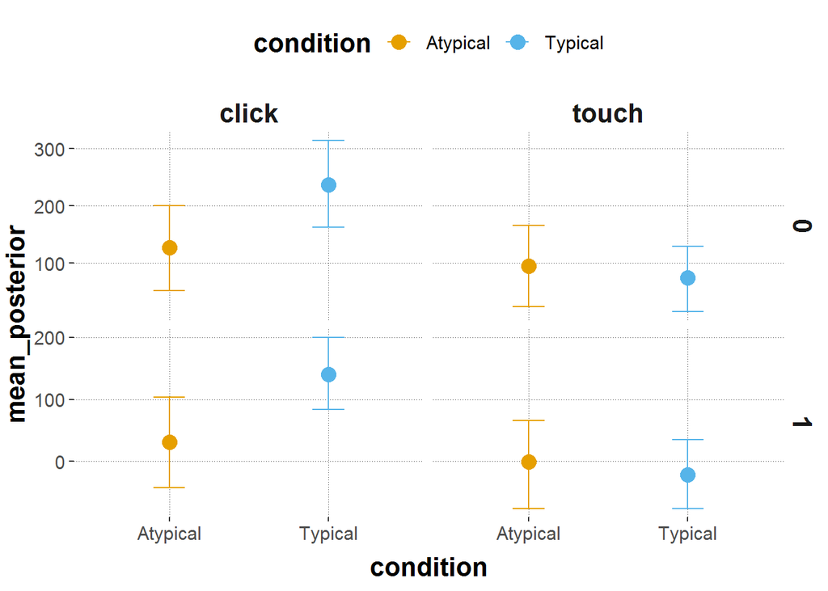

```r
posteriors1 <- model %>%
  spread_draws(b_Intercept,
               b_conditionTypical,
               b_grouptouch, b_correct1, `b_conditionTypical:grouptouch`) %>%
  # calculate posteriors for each individual level
  mutate(Atypical_click0 = b_Intercept,
         Typical_click0 = b_Intercept + b_conditionTypical,
         Atypical_touch0 = b_Intercept + b_grouptouch,
         Typical_touch0 = b_Intercept + b_conditionTypical + b_grouptouch + `b_conditionTypical:grouptouch`,
         Atypical_click1 = b_Intercept + b_correct1,
         Typical_click1 = b_Intercept + b_correct1 + b_conditionTypical,
         Atypical_touch1 = b_Intercept + b_correct1 + b_grouptouch,
         Typical_touch1 = b_Intercept + b_correct1 + b_conditionTypical + b_grouptouch + `b_conditionTypical:grouptouch`) %>%
  select(Atypical_click0, Typical_click0,
         Atypical_touch0, Typical_touch0,
         Atypical_click1, Typical_click1,
         Atypical_touch1, Typical_touch1) %>%
  gather(key = "parameter", value = "posterior") %>%
  mutate(group = ifelse(parameter == "Atypical_click0" | parameter == "Typical_click0" | parameter  == "Atypical_click1"| parameter == "Typical_click1",
                        "click", "touch"),
         condition = ifelse(parameter == "Atypical_click0"| parameter == "Atypical_touch0" |parameter == "Atypical_click1"| parameter == "Atypical_touch1",
                        "Atypical", "Typical"),
         correct = ifelse(parameter == "Atypical_click0"|parameter == "Atypical_touch0"|parameter == "Typical_click0"| parameter == "Typical_touch0",
                        "0", "1"))


posteriors1_agg <- posteriors1 %>%
  group_by(group, condition, correct) %>%
  summarise(mean_posterior = mean(posterior),
            `95lowerCrI` = HDInterval::hdi(posterior, credMass = 0.95)[1],
            `95higherCrI` = HDInterval::hdi(posterior, credMass = 0.95)[2])


ggplot(data = posteriors1_agg,
       aes(x = condition, y = mean_posterior,
           color = condition, fill = condition), position = position_dodge(width = 0.5)) +
  geom_errorbar(aes(ymin = `95lowerCrI`, ymax = `95higherCrI`),
                width = 0.2) +
  geom_point( alpha = 1, size = 4) +
  facet_grid(correct~group, scale = "free")
```

5. Create a point plot that plots the data against the posterior means and 95% CrIs.

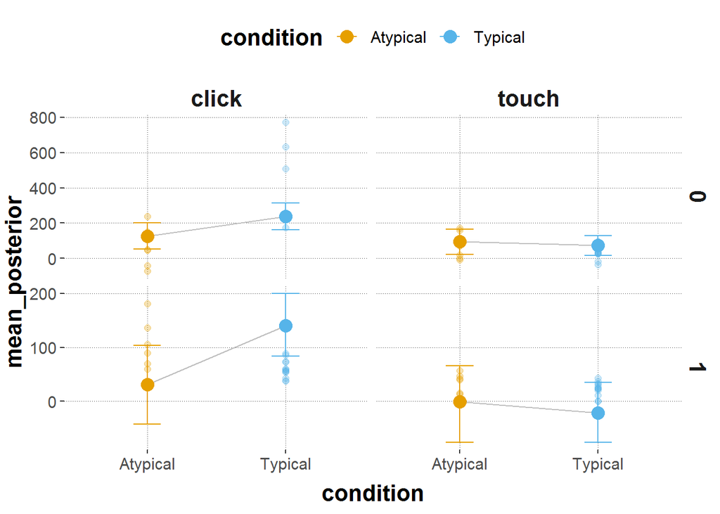

```r
ggplot(data = posteriors1_agg,
       aes(x = condition, y = mean_posterior,
           color = condition, fill = condition), position = position_dodge(width = 0.5)) +
  geom_errorbar(aes(ymin = `95lowerCrI`, ymax = `95higherCrI`),
                width = 0.2) +
  geom_line(aes(group = group), color = "grey") +
  geom_point(size = 4) +
  geom_point(data = dolphin_agg2,  aes(x = condition, y = MAD), alpha = 0.3, size = 2) +
  facet_grid(correct~group, scale = "free")
```

Bonus: (f) run the model with a three-way interaction `group x condition x correct`. Extract the posteriors for each individual combination of predictor levels and plot them against the data as in 2d.

```r
model3 = brm(
  # model formula
  MAD ~ condition * group * correct,
  # data
  data = dolphin_agg2,
  seed = 991,
  iter   = 2000,
  chains = 4
  )
summary(model3)
```

```
##  Family: gaussian
##   Links: mu = identity; sigma = identity
## Formula: MAD ~ condition * group * correct
##    Data: dolphin_agg2 (Number of observations: 65)
## Samples: 4 chains, each with iter = 2000; warmup = 1000; thin = 1;
##          total post-warmup samples = 4000
##
## Population-Level Effects:
##                                      Estimate Est.Error l-95% CI u-95% CI
## Intercept                               59.66     32.32    -5.11   120.32
## conditionTypical                       457.12     48.59   362.99   554.21
## grouptouch                               6.61     45.07   -85.40    94.62
## correct1                                44.79     45.17   -43.36   135.07
## conditionTypical:grouptouch           -492.00     62.35  -614.20  -367.11
## conditionTypical:correct1             -503.37     62.30  -626.32  -382.94
## grouptouch:correct1                    -77.98     64.16  -198.04    51.52
## conditionTypical:grouptouch:correct1   525.69     84.20   360.08   691.13
##                                      Rhat Bulk_ESS Tail_ESS
## Intercept                            1.00     1789     2260
## conditionTypical                     1.00     1433     1553
## grouptouch                           1.00     1561     2123
## correct1                             1.00     1446     1904
## conditionTypical:grouptouch          1.00     1295     1525
## conditionTypical:correct1            1.00     1272     1438
## grouptouch:correct1                  1.00     1394     1557
## conditionTypical:grouptouch:correct1 1.00     1254     1246
##
## Family Specific Parameters:
##       Estimate Est.Error l-95% CI u-95% CI Rhat Bulk_ESS Tail_ESS
## sigma    75.91      7.32    63.67    92.03 1.00     2095     2030
##
## Samples were drawn using sampling(NUTS). For each parameter, Bulk_ESS
## and Tail_ESS are effective sample size measures, and Rhat is the potential
## scale reduction factor on split chains (at convergence, Rhat = 1).
```

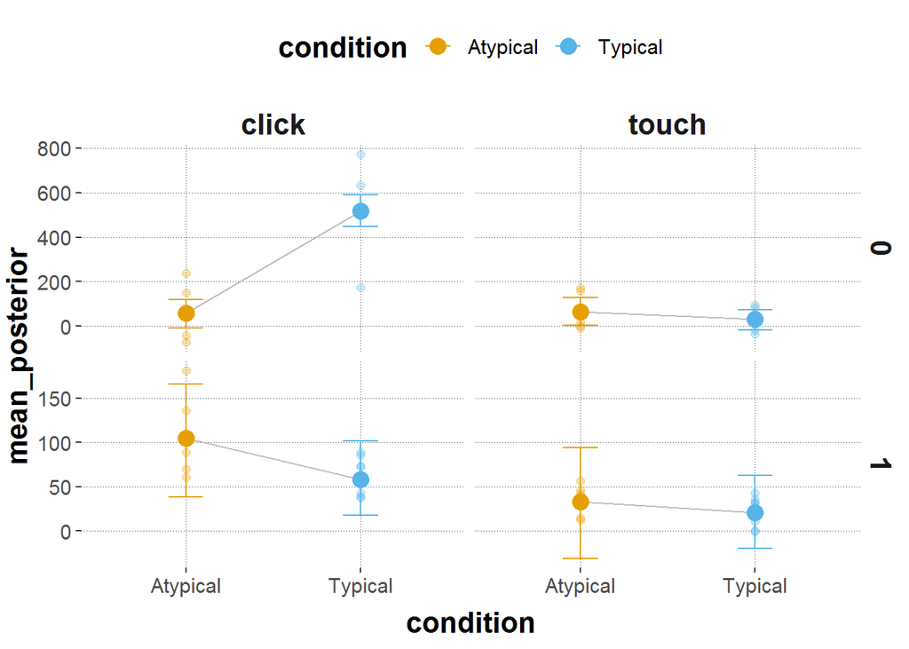

```r
posteriors3 <- model3 %>%
  spread_draws(b_Intercept,
               b_conditionTypical,
               b_grouptouch, b_correct1, `b_conditionTypical:grouptouch`, `b_conditionTypical:correct1`, `b_grouptouch:correct1`, `b_conditionTypical:grouptouch:correct1`) %>%
  # calculate posteriors for each individual level
  mutate(Atypical_click0 = b_Intercept,
         Typical_click0 = b_Intercept + b_conditionTypical,
         Atypical_touch0 = b_Intercept + b_grouptouch,
         Typical_touch0 = b_Intercept + b_conditionTypical + b_grouptouch + `b_conditionTypical:grouptouch`,
         Atypical_click1 = b_Intercept + b_correct1,
         Typical_click1 = b_Intercept + b_correct1 + b_conditionTypical + `b_conditionTypical:correct1`,
         Atypical_touch1 = b_Intercept + b_correct1 + b_grouptouch + `b_grouptouch:correct1` ,
         Typical_touch1 = b_Intercept + b_correct1 + b_conditionTypical + b_grouptouch + `b_conditionTypical:correct1` + `b_grouptouch:correct1` + `b_conditionTypical:grouptouch:correct1`+ `b_conditionTypical:grouptouch`) %>%
  select(Atypical_click0, Typical_click0,
         Atypical_touch0, Typical_touch0,
         Atypical_click1, Typical_click1,
         Atypical_touch1, Typical_touch1) %>%
  gather(key = "parameter", value = "posterior") %>% mutate(group = ifelse(parameter == "Atypical_click0" | parameter == "Typical_click0" | parameter  == "Atypical_click1"| parameter == "Typical_click1",
                        "click", "touch"),
         condition = ifelse(parameter == "Atypical_click0"| parameter == "Atypical_touch0" |parameter == "Atypical_click1"| parameter == "Atypical_touch1",
                        "Atypical", "Typical"),
         correct = ifelse(parameter == "Atypical_click0"|parameter == "Atypical_touch0"|parameter == "Typical_click0"| parameter == "Typical_touch0",
                        "0", "1"))


posteriors3_agg <- posteriors3 %>%
  group_by(group, condition, correct) %>%
  summarise(mean_posterior = mean(posterior),
            `95lowerCrI` = HDInterval::hdi(posterior, credMass = 0.95)[1],
            `95higherCrI` = HDInterval::hdi(posterior, credMass = 0.95)[2])


ggplot(data = posteriors3_agg,
       aes(x = condition, y = mean_posterior,
           color = condition, fill = condition), position = position_dodge(width = 0.5)) +
  geom_errorbar(aes(ymin = `95lowerCrI`, ymax = `95higherCrI`),
                width = 0.2) +
  geom_line(aes(group = group), color = "grey") +
  geom_point(size = 4) +
  geom_point(data = dolphin_agg2,  aes(x = condition, y = MAD), alpha = 0.3, size = 2) +
  facet_grid(correct~group, scale = "free")
```